# WHEN AND WHICH USER TOOK MOST TRIPS

## by Emmanuel De-Graft

## Investigation Overview

The dataset shows that all riders started their trips in the month of February and ended in the month of March. In the investigation, I looked at that the days of the week and the day of the month where most riders started and ended their trips. I also looked at the type of user (Subscriber or Customer) who took the most trips as well as the age of the riders.

## Dataset Overview

The dataset include the trips duration and features for about 175,070 trips. The features include start date, end date, member gender, user type. I extrapolated the day of the week, the day of the month and the hour of day from the date as well as the member age from the member date of birth and the start date. 8,342 data points were removed from the dataset during wrangling because of empty values and inconsistent data.

## Distribution of the Start day of the Week

Start day of the week shows a close marking between Saturday and Sunday in frequency and they are relatively low to the other days of the week. However, Thursday has the highest frequency typifying more riders taking trips on Thursday of the month of February. The distribution is identical for the end day of the week, thus, more riders also completed trips on Thursday of the month of March.

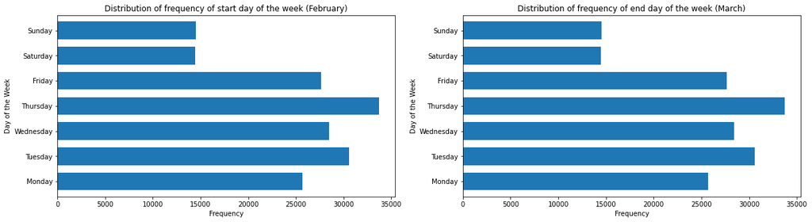

## Distribution of the Start and End day of the Month

From the month of February, there is a group rise and fall consecutively through the days in the month. There is a similar progression in the end month of March. The visualisation shows that mopst riders took rides on the 28th of February and ended on the 28th of March.

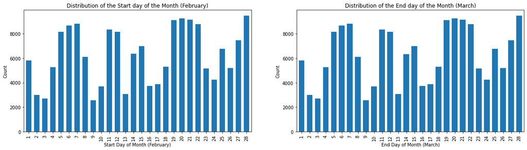

## Distribution of the User Type

The user type distribution is visualized on a pie chart with the percentages indicated on their corresponding wedges. The percentage of subscribers is portrayed to have a greater percentage of 81% greater than that of customers. Thus, a greater portion of the riders who took the trip are subscribers.

[figure not shown]

## Distribution of the member age

The distribution of the member age is skewed to the right, depicting that the most riders who took trips were between the ages of 20 and 50. The distribution however, has a tail end with less riders within ages greater than 70.

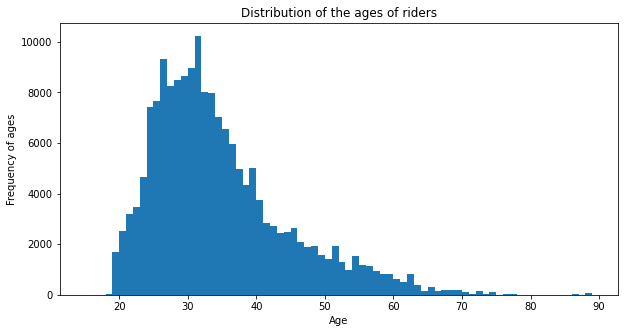

## Distribution of the duration of the average trip

After converting the duration from seconds to minutes, the average duration of trips is approximately 11.74 inutes, thus the average trip take about 11.74 minutes.

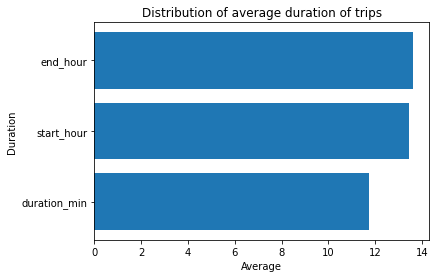